# Demulticoder 16S Mothur SOP Validation

2024-12-24

Input metadata and primerinfo_params files are in data folder

The only required columns are the first with sample names, and the second with the primer name/barcode used. The subsequent columns are user-specific columns for downstream steps *metadata.csv file*

| sample_name | primer_name | Day | When |
| --- | --- | --- | --- |
| F3D0 | r16S | 0 | Early |
| F3D1 | r16S | 1 | Early |
| F3D141 | r16S | 141 | Late |
| F3D142 | r16S | 142 | Late |
| F3D143 | r16S | 143 | Late |
| F3D144 | r16S | 144 | Late |
| F3D145 | r16S | 145 | Late |
| F3D146 | r16S | 146 | Late |
| F3D147 | r16S | 147 | Late |
| F3D148 | r16S | 148 | Late |
| F3D149 | r16S | 149 | Late |
| F3D150 | r16S | 150 | Late |
| F3D2 | r16S | 2 | Early |
| F3D3 | r16S | 3 | Early |
| F3D5 | r16S | 5 | Early |
| F3D6 | r16S | 6 | Early |
| F3D7 | r16S | 7 | Early |
| F3D8 | r16S | 8 | Early |
| F3D9 | r16S | 9 | Early |
| Mock | r16S | NA | NA |

I then included the necessary second file with the name of the barcode selected, primer sequences, and the optional DADA2 parameter options. I referenced the DADA2 [tutorial](https://benjjneb.github.io/dada2/tutorial.html) to select the proper parameter options.

Note, primers were already trimmed from reads, but just to be certain, I included the Earth Microbiome primers described [here](https://earthmicrobiome.org/protocols-and-standards/16s/), and a few primer sequences were still found within a small number of reads. *primerinfo_params.csv*

| primer_name | forward | reverse | already_trimmed | minCutadaptlength | multithread | verbose | maxN | maxEE_forward | maxEE_reverse | truncLen_forward | truncLen_reverse | truncQ | minLen | maxLen | minQ | trimLeft | trimRight | rm.lowcomplex | minOverlap | maxMismatch | min_asv_length |
| --- | --- | --- | --- | --- | --- | --- | --- | --- | --- | --- | --- | --- | --- | --- | --- | --- | --- | --- | --- | --- | --- |
| r16S | GTGYCAGCMGCCGCGGTAA | GGACTACNVGGGTWTCTAAT | TRUE | 50 | TRUE | TRUE | 0 | 2 | 2 | 240 | 160 | 2 | 20 | Inf | 0 | 0 | 0 | 0 | 12 | 0 | 50 |

### Step 1-Remove N’s and create directory structure for downstream steps

```r
outputs<-prepare_reads(
  data_directory = "~/benchmark_demulticoder/mothur_16S_sop/data",
  output_directory = "~/benchmark_demulticoder/mothur_16S_sop/outputs_demulticoder",
  overwrite_existing = TRUE)
```

```
## Creating output directory: /var/folders/59/9jp4sjjd00n2wp4kgqtvq7dh0000gn/T//RtmpoPRwrR/demulticoder_run/prefiltered_sequences
##
##
```

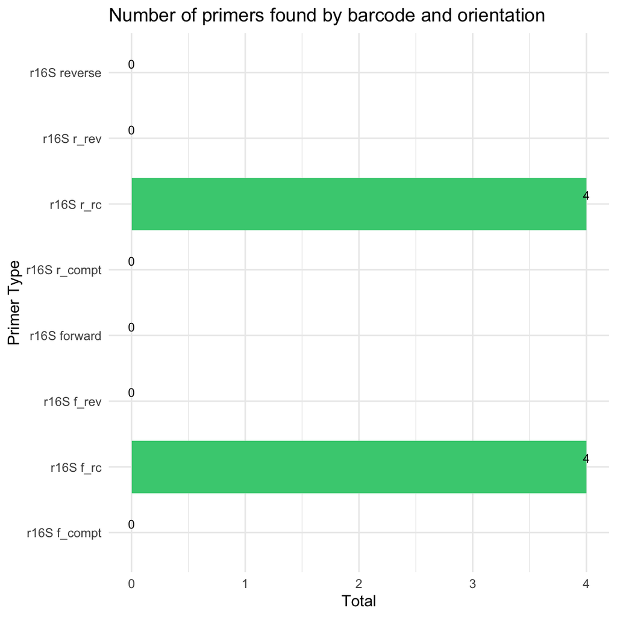

### Step 2-Run Cutadapt to remove primers and then trim reads with DADA2 filterAndTrim function

```r
cut_trim(
  outputs,
  cutadapt_path="/opt/homebrew/bin/cutadapt",
  overwrite_existing = TRUE)
```

[output not shown]

[output cut: 14 more lines]

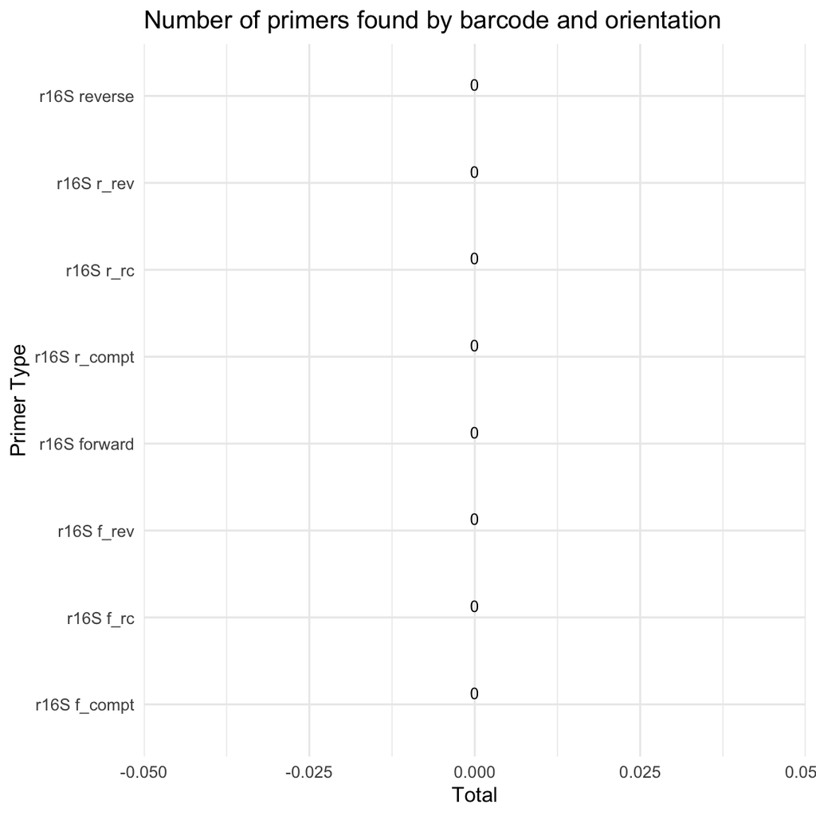

### Step 3-Core ASV inference step

```r
make_asv_abund_matrix(
  outputs,
  overwrite_existing = TRUE)
```

```
## 33513360 total bases in 139639 reads from 20 samples will be used for learning the error rates.
## Initializing error rates to maximum possible estimate.
## selfConsist step 1 ....................
##    selfConsist step 2
##    selfConsist step 3
##    selfConsist step 4
##    selfConsist step 5
## Convergence after  5  rounds.
## Error rate plot for the Forward read of primer pair r16S
```

```
## Sample 1 - 7112 reads in 1978 unique sequences.
## Sample 2 - 5299 reads in 1639 unique sequences.
## Sample 3 - 5463 reads in 1477 unique sequences.
## Sample 4 - 2914 reads in 904 unique sequences.
## Sample 5 - 2941 reads in 939 unique sequences.
## Sample 6 - 4312 reads in 1267 unique sequences.
## Sample 7 - 6741 reads in 1756 unique sequences.
## Sample 8 - 4560 reads in 1438 unique sequences.
## Sample 9 - 15636 reads in 3589 unique sequences.
## Sample 10 - 11412 reads in 2761 unique sequences.
## Sample 11 - 12017 reads in 3021 unique sequences.
## Sample 12 - 5032 reads in 1566 unique sequences.
## Sample 13 - 18075 reads in 3707 unique sequences.
## Sample 14 - 6250 reads in 1479 unique sequences.
## Sample 15 - 4052 reads in 1195 unique sequences.
## Sample 16 - 7369 reads in 1832 unique sequences.
## Sample 17 - 4765 reads in 1183 unique sequences.
## Sample 18 - 4871 reads in 1382 unique sequences.
## Sample 19 - 6504 reads in 1709 unique sequences.
## Sample 20 - 4314 reads in 897 unique sequences.
## 22342240 total bases in 139639 reads from 20 samples will be used for learning the error rates.
## Initializing error rates to maximum possible estimate.
## selfConsist step 1 ....................
##    selfConsist step 2
##    selfConsist step 3
##    selfConsist step 4
##    selfConsist step 5
##    selfConsist step 6
##    selfConsist step 7
## Convergence after  7  rounds.
## Error rate plot for the Reverse read of primer pair r16S
```

```
## Sample 1 - 7112 reads in 1659 unique sequences.
## Sample 2 - 5299 reads in 1349 unique sequences.
## Sample 3 - 5463 reads in 1335 unique sequences.
## Sample 4 - 2914 reads in 853 unique sequences.
## Sample 5 - 2941 reads in 880 unique sequences.
## Sample 6 - 4312 reads in 1286 unique sequences.
## Sample 7 - 6741 reads in 1803 unique sequences.
## Sample 8 - 4560 reads in 1265 unique sequences.
## Sample 9 - 15636 reads in 3413 unique sequences.
## Sample 10 - 11412 reads in 2522 unique sequences.
## Sample 11 - 12017 reads in 2771 unique sequences.
## Sample 12 - 5032 reads in 1415 unique sequences.
## Sample 13 - 18075 reads in 3290 unique sequences.
## Sample 14 - 6250 reads in 1390 unique sequences.
## Sample 15 - 4052 reads in 1134 unique sequences.
## Sample 16 - 7369 reads in 1635 unique sequences.
## Sample 17 - 4765 reads in 1084 unique sequences.
## Sample 18 - 4871 reads in 1161 unique sequences.
## Sample 19 - 6504 reads in 1502 unique sequences.
## Sample 20 - 4314 reads in 732 unique sequences.
```

```
## 6540 paired-reads (in 107 unique pairings) successfully merged out of 6891 (in 197 pairings) input.
```

```
## 5027 paired-reads (in 101 unique pairings) successfully merged out of 5189 (in 157 pairings) input.
```

```
## 4986 paired-reads (in 81 unique pairings) successfully merged out of 5267 (in 166 pairings) input.
```

```
## 2595 paired-reads (in 52 unique pairings) successfully merged out of 2754 (in 108 pairings) input.
```

```
## 2553 paired-reads (in 60 unique pairings) successfully merged out of 2785 (in 119 pairings) input.
```

```
## 3646 paired-reads (in 55 unique pairings) successfully merged out of 4109 (in 157 pairings) input.
```

```
## 6079 paired-reads (in 81 unique pairings) successfully merged out of 6514 (in 198 pairings) input.
```

```
## 3968 paired-reads (in 91 unique pairings) successfully merged out of 4388 (in 187 pairings) input.
```

```
## 14233 paired-reads (in 143 unique pairings) successfully merged out of 15355 (in 352 pairings) input.
```

```
## 10529 paired-reads (in 120 unique pairings) successfully merged out of 11165 (in 277 pairings) input.
```

```
## 11154 paired-reads (in 137 unique pairings) successfully merged out of 11797 (in 298 pairings) input.
```

```
## 4349 paired-reads (in 85 unique pairings) successfully merged out of 4802 (in 179 pairings) input.
```

```
## 17431 paired-reads (in 153 unique pairings) successfully merged out of 17812 (in 272 pairings) input.
```

```
## 5850 paired-reads (in 81 unique pairings) successfully merged out of 6095 (in 159 pairings) input.
```

```
## 3713 paired-reads (in 86 unique pairings) successfully merged out of 3891 (in 147 pairings) input.
```

```
## 6865 paired-reads (in 99 unique pairings) successfully merged out of 7191 (in 187 pairings) input.
```

```
## 4428 paired-reads (in 68 unique pairings) successfully merged out of 4605 (in 128 pairings) input.
```

```
## 4576 paired-reads (in 101 unique pairings) successfully merged out of 4739 (in 174 pairings) input.
```

```
## 6092 paired-reads (in 109 unique pairings) successfully merged out of 6315 (in 173 pairings) input.
```

```
## 4269 paired-reads (in 20 unique pairings) successfully merged out of 4281 (in 28 pairings) input.
```

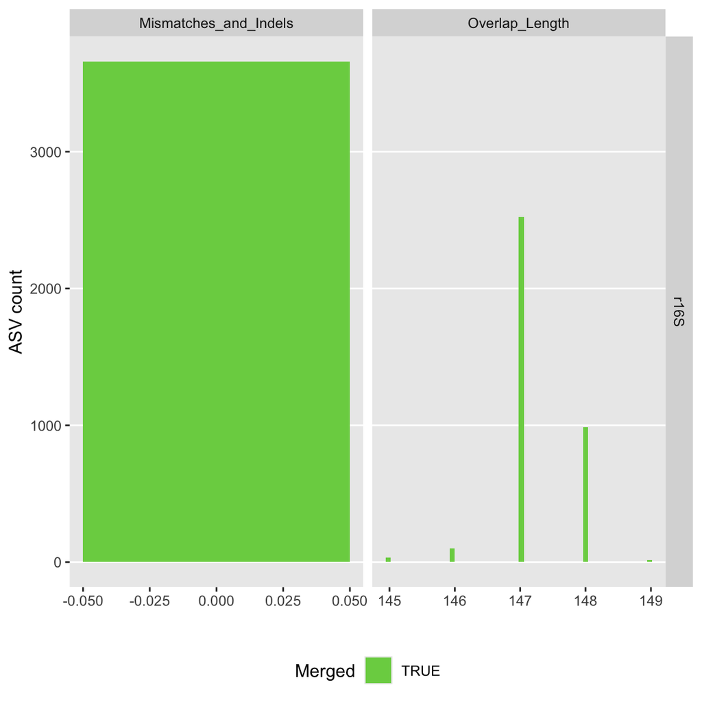

```
## Identified 61 bimeras out of 293 input sequences.
```

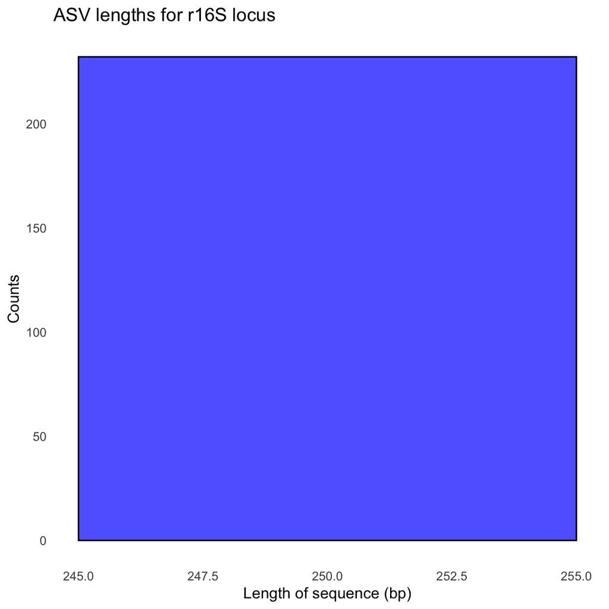

```
## $r16S
## [1] "/var/folders/59/9jp4sjjd00n2wp4kgqtvq7dh0000gn/T//RtmpoPRwrR/demulticoder_run/asvabund_matrixDADA2_r16S.RData"
```

### Step 4-Assign taxonomy step

```r
assign_tax(
  outputs,
  asv_abund_matrix,
  db_16S="silva_nr99_v138.2_toSpecies_trainset.fa.gz",
  retrieve_files=TRUE,
  overwrite_existing=TRUE)
```

```
##    samplename_barcode input filtered denoisedF denoisedR merged nonchim
## 1           F3D0_r16S  7733     7112      6976      6979   6540    6528
## 2           F3D1_r16S  5829     5299      5226      5239   5027    5016
## 3         F3D141_r16S  5926     5463      5331      5357   4986    4863
## 4         F3D142_r16S  3158     2914      2799      2830   2595    2521
## 5         F3D143_r16S  3164     2941      2822      2868   2553    2519
## 6         F3D144_r16S  4798     4312      4150      4228   3646    3507
## 7         F3D145_r16S  7331     6741      6592      6627   6079    5820
## 8         F3D146_r16S  4993     4560      4450      4470   3968    3879
## 9         F3D147_r16S 16956    15636     15433     15505  14233   13006
## 10        F3D148_r16S 12332    11412     11250     11267  10529    9935
## 11        F3D149_r16S 13006    12017     11857     11898  11154   10653
## 12        F3D150_r16S  5474     5032      4879      4925   4349    4240
## 13          F3D2_r16S 19489    18075     17907     17939  17431   16835
## 14          F3D3_r16S  6726     6250      6145      6176   5850    5486
## 15          F3D5_r16S  4418     4052      3930      3991   3713    3713
## 16          F3D6_r16S  7933     7369      7231      7294   6865    6678
## 17          F3D7_r16S  5103     4765      4646      4673   4428    4217
## 18          F3D8_r16S  5274     4871      4786      4802   4576    4547
## 19          F3D9_r16S  7023     6504      6341      6442   6092    6015
## 20          Mock_r16S  4748     4314      4287      4286   4269    4269
```

### Step 5-convert asv matrix to taxmap and phyloseq objects with one function

```r
objs<-convert_asv_matrix_to_objs(outputs, save_outputs=TRUE, overwrite_existing = TRUE)
```

```
## For r16S dataset
## Taxmap object saved in: ~/benchmark_demulticoder/mothur_16S_sop/outputs_demulticoder/taxmap_obj_r16S.RData
## Phyloseq object saved in: ~/benchmark_demulticoder/mothur_16S_sop/outputs_demulticoder/phylo_obj_r16S.RData
## ASVs filtered by minimum read depth: 0
## For taxonomic assignments, if minimum bootstrap was set to: 0 assignments were set to 'Unsupported'
## ~~~~~~~~~~~~~~~~~~~~~~~~~~~~~~~~~~~~
```

### Step 6-evaluate accuracy using mock community, as shown in dada2 tutorial

```r
library(Biostrings); packageVersion("Biostrings")
```

```
## [1] '2.70.3'
```

```r
tax_matrix<-read.csv("~/benchmark_demulticoder/mothur_16S_sop/outputs_demulticoder/final_asv_abundance_matrix_r16S.csv")

unqs.mock <- tax_matrix[, c(2, which(colnames(tax_matrix) == "Mock_r16S"))]

unqs.mock <- unqs.mock[unqs.mock$Mock_r16S != 0,]

cat("DADA2 inferred", nrow(unqs.mock), "sample sequences present in the Mock community.\n")
```

```
## DADA2 inferred 20 sample sequences present in the Mock community.
```

```r
mock.ref <- dada2::getSequences(file.path("mothur_16S_sop/data", "HMP_MOCK.v35.fasta"))
match.ref <- sum(sapply(unqs.mock$sequence, function(x) any(grepl(x, mock.ref))))
cat("Of those,", sum(match.ref), "were exact matches to the expected reference sequences.\n")
```

```
## Of those, 0 were exact matches to the expected reference sequences.
```

### Step 7-Follow-up work using phyloseq to do side-by-side comparison with dada2 example and to examine alpha diversity results

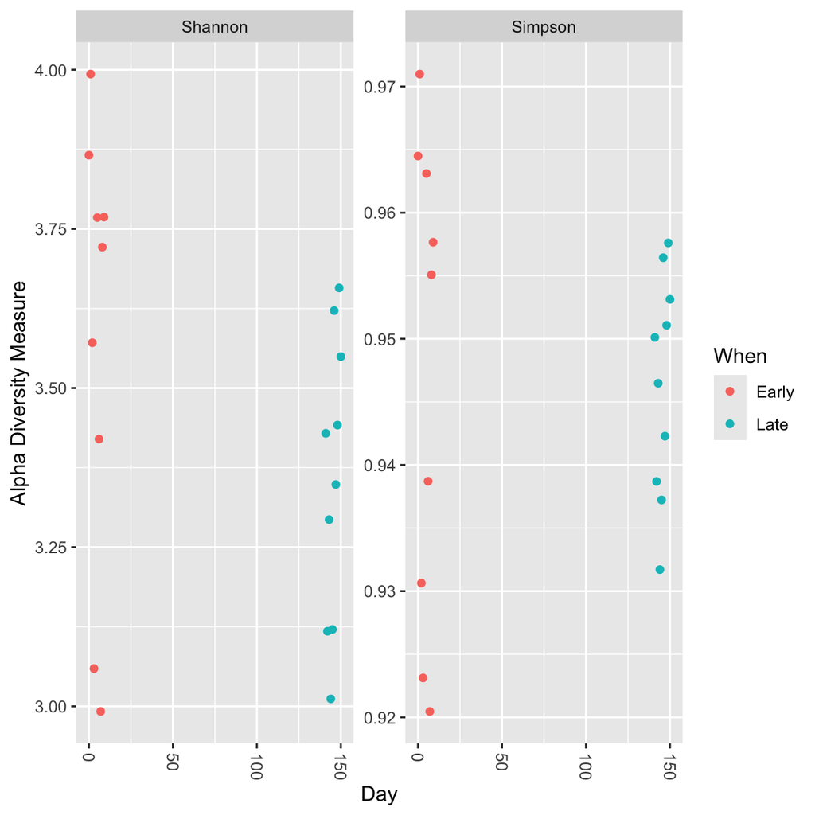

```r
#Let's prune mock community sample
objs$phyloseq_r16S <- phyloseq::prune_samples(phyloseq::sample_names(objs$phyloseq_r16S) != "Mock_r16S", objs$phyloseq_r16S) # Remove mock sample
phyloseq::plot_richness(objs$phyloseq_r16S, x="Day", measures=c("Shannon", "Simpson"), color="When")
```

### Step 8-Examine ordination plots as additional point of comparison with DADA2 tutorial

```r
# Transform data to proportions as appropriate for Bray-Curtis distances
ps.prop <- phyloseq::transform_sample_counts(objs$phyloseq_r16S, function(otu) otu/sum(otu))
ord.nmds.bray <- phyloseq::ordinate(ps.prop, method="NMDS", distance="bray")
```

```
## *** Best solution repeated 2 times
```

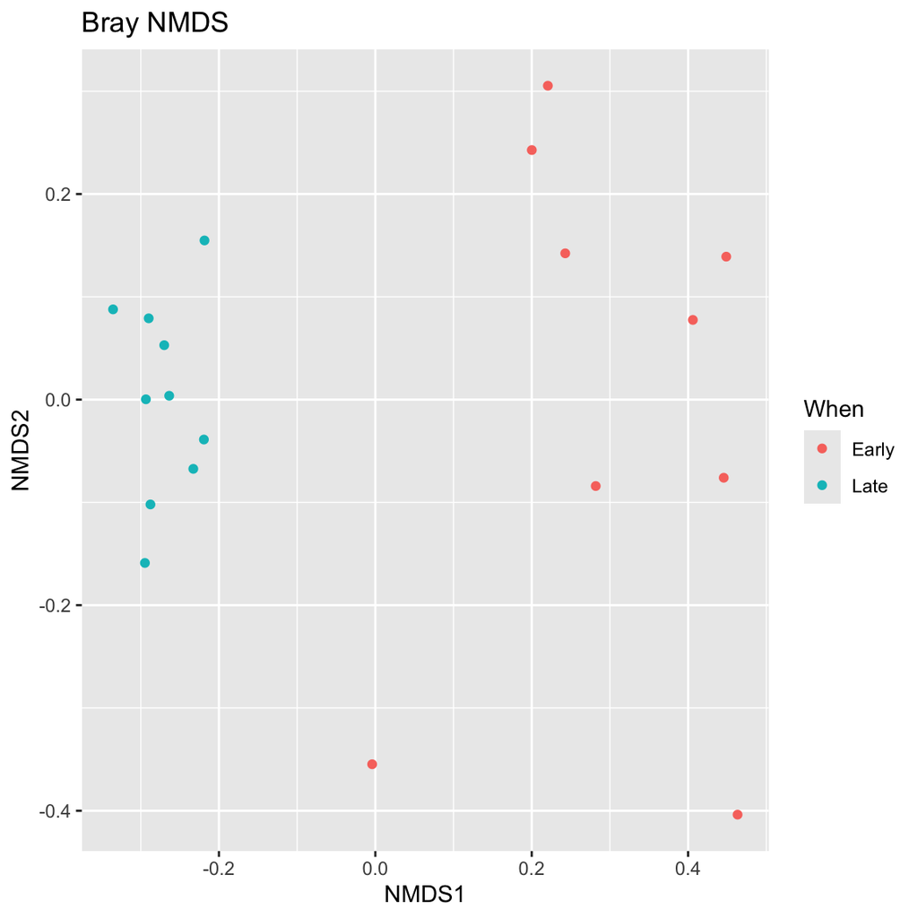

```r
phyloseq::plot_ordination(ps.prop, ord.nmds.bray, color="When", title="Bray NMDS")
```

### Step 9-Let’s look at what the top 20 taxa are in the early vs. late samples time points, as shown in the dada2 tutorial

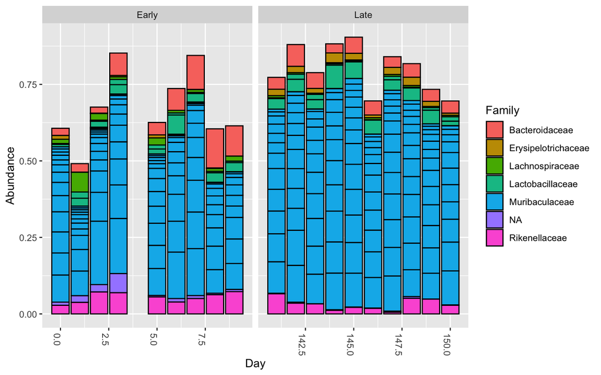

```r
top20 <- names(sort(phyloseq::taxa_sums(objs$phyloseq_r16S), decreasing=TRUE))[1:20]
ps.top20 <- phyloseq::transform_sample_counts(objs$phyloseq_r16S, function(OTU) OTU/sum(OTU))
ps.top20 <- phyloseq::prune_taxa(top20, ps.top20)
phyloseq::plot_bar(ps.top20, x="Day", fill="Family") + ggplot2::facet_wrap(~When, scales="free_x")
```